# A Study of Using Basic Machine Learning on Quantified Self Movement: How Well People Exercise

Rui Qiu

2017-02-27

## Executive Summary

Based on the data from http://groupware.les.inf.puc-rio.br/har, we want to predict the manner in which test subjects did the exercise. Basically, the algorithm itself is going to classify the variables in the testing set, after learning features from the training set.

## Data Preprocessing

```r
library(caret)
library(rpart)
library(rpart.plot)
library(randomForest)
library(corrplot)
```

## Processing Data

### Data Import

The data is provided by http://groupware.les.inf.puc-rio.br/har.

- Specifically, the training data is [here](https://d396qusza40orc.cloudfront.net/predmachlearn/pml-training.csv).
- The testing data is [here](https://d396qusza40orc.cloudfront.net/predmachlearn/pml-testing.csv).

```r
train0 <- read.csv("pml-training.csv")
test0 <- read.csv("pml-testing.csv")
dim(train0)
```

```
## [1] 19622   160
```

```r
dim(test0)
```

```
## [1]  20 160
```

The training data has 19622 observations and 160 variables.

The testing data has 20 observations and 160 variables as well.

Our goal is to predict the variable `classe` of testing data after training our algorithm in the training data.

### Data Cleaning and Data Manipulation

After loading data, we

- delete columns in training data that have missing values
- remove predictors with little predicting power over `classe`
- divide training data into two partitions with a 7:3 ratio. 70% of training data will used purely for training, the 30% left will used for validation

The testing data would be loaded until the final test (the quiz problems).

```r
sum(complete.cases(train0))
```

```
## [1] 406
```

```r
train0 <- train0[, colSums(is.na(train0)) == 0]
test0 <- test0[, colSums(is.na(test0)) == 0]

classe <- train0$classe
train_delete <- grepl("^X|timestamp|window", names(train0))
train0 <- train0[, !train_delete]
train1 <- train0[, sapply(train0, is.numeric)]
train1$classe <- classe
test_delete <- grepl("^X|timestamp|window", names(test0))
test0 <- test0[, !test_delete]
test1 <- test0[, sapply(test0, is.numeric)]

set.seed(22519) # For reproducibile purpose
inTrain <- createDataPartition(train1$classe, p=0.70, list=F)
toTrain <- train1[inTrain, ]
toValid <- train1[-inTrain, ]
```

## Prediction Algorithm (5-fold Random Forest)

The reason why we should choose random forest here is because it automatically picks vital variables out and it is quite robust when dealing with correlated covariates and outliers.

```r
control <- trainControl(method="cv", 5)
forestModel <- train(classe ~ ., data=toTrain, method="rf", trControl=control, ntree=250)
forestModel
```

```
## Random Forest
##
## 13737 samples
##    52 predictor
##     5 classes: 'A', 'B', 'C', 'D', 'E'
##
## No pre-processing
## Resampling: Cross-Validated (5 fold)
## Summary of sample sizes: 10989, 10989, 10991, 10990, 10989
## Resampling results across tuning parameters:
##
##   mtry  Accuracy   Kappa
##    2    0.9901727  0.9875673
##   27    0.9917015  0.9895017
##   52    0.9840572  0.9798282
##
## Accuracy was used to select the optimal model using  the largest value.
## The final value used for the model was mtry = 27.
```

Predict over validation set.

```r
predictForest <- predict(forestModel, toValid)
confusionMatrix(toValid$classe, predictForest)
```

```
## Confusion Matrix and Statistics
##
##           Reference
## Prediction    A    B    C    D    E
##          A 1673    0    0    0    1
##          B    5 1131    3    0    0
##          C    0    0 1021    5    0
##          D    0    0   13  949    2
##          E    0    0    1    6 1075
##
## Overall Statistics
##
##                Accuracy : 0.9939
##                  95% CI : (0.9915, 0.9957)
##     No Information Rate : 0.2851
##     P-Value [Acc > NIR] : < 2.2e-16
##
##                   Kappa : 0.9923
##  Mcnemar's Test P-Value : NA
##
## Statistics by Class:
##
##                      Class: A Class: B Class: C Class: D Class: E
## Sensitivity            0.9970   1.0000   0.9836   0.9885   0.9972
## Specificity            0.9998   0.9983   0.9990   0.9970   0.9985
## Pos Pred Value         0.9994   0.9930   0.9951   0.9844   0.9935
## Neg Pred Value         0.9988   1.0000   0.9965   0.9978   0.9994
## Prevalence             0.2851   0.1922   0.1764   0.1631   0.1832
## Detection Rate         0.2843   0.1922   0.1735   0.1613   0.1827
## Detection Prevalence   0.2845   0.1935   0.1743   0.1638   0.1839
## Balanced Accuracy      0.9984   0.9992   0.9913   0.9927   0.9979
```

Show accuracy of our algorithm.

```r
accuracy <- postResample(predictForest, toValid$classe)
accuracy
```

```
##  Accuracy     Kappa
## 0.9938828 0.9922620
```

```r
error <- 1 - as.numeric(confusionMatrix(toValid$classe, predictForest)$overall[1])
error
```

```
## [1] 0.006117247
```

The accuracy of our 5-fold random forest is approximately 99.39% and the out-of-sample error is 0.61%.

## Test on Test Data

We now apply the model to the real testing data.

```r
# Remove problem_id
result <- predict(forestModel, test1[, -length(names(test1))])
result
```

```
##  [1] B A B A A E D B A A B C B A E E A B B B
## Levels: A B C D E
```

## Conclusion

The predicted for 20 tests subjects are:

```
B A B A A E D B A A B C B A E E A B B B
```

## Appendices

Correlation Matrix

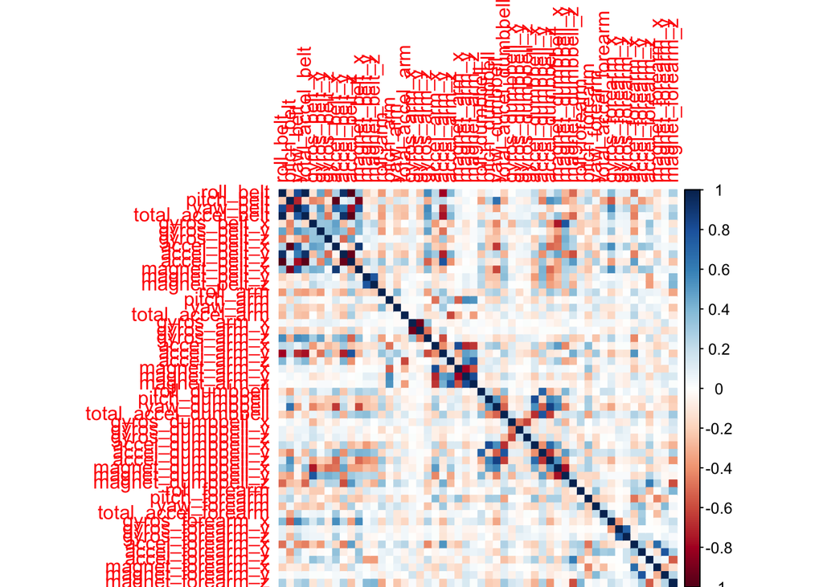

```r
corrPlot <- cor(toTrain[, -length(names(toTrain))])
corrplot(corrPlot, method="color")
```